# Data 621 - Homework 5

Dhairav Chhatbar, Mael Illien, Salma Elshahawy

11/23/2020

# Data 621 Homework5

## Introduction

In this assignment, we are tasked with predicting the number of cases of wine sold to wine distribution companies following a sampling. The target variable, cases of wine sold, is count data and therefore will be modeled using appropriate techniques such as Poisson and Negative Binomial regressions.

```r
data_train <- read.csv("https://raw.githubusercontent.com/salma71/Data_621/master/HW_5/wine-training-data.csv", header = TRUE)
data_test <- read.csv("https://raw.githubusercontent.com/salma71/Data_621/master/HW_5/wine-evaluation-data.csv", header = TRUE)
```

## Data Exploration

### Data Exploration

All the variable in this dataset are numeric and continuous except for `AcidIndex`, `STARS` and `LabelAppeal` which are discrete. The target variable `TARGET` is also discrete. There are a number of missing observations for certain chemical compositiion variables as well as a large number of wines with no `STARS` rating. The distribution of the continous variables appear well centered.

```r
skim(data_train)
```

Data summary

| Name | data_train |
| --- | --- |
| Number of rows | 12795 |
| Number of columns | 16 |
| _______________________ |  |
| Column type frequency: |  |
| numeric | 16 |
| ________________________ |  |
| Group variables | None |

**Variable type: numeric**

| skim_variable | n_missing | complete_rate | mean | sd | p0 | p25 | p50 | p75 | p100 | hist |
| --- | --- | --- | --- | --- | --- | --- | --- | --- | --- | --- |
| INDEX | 0 | 1.00 | 8069.98 | 4656.91 | 1.00 | 4037.50 | 8110.00 | 12106.50 | 16129.00 | ▇▇▇▇▇ |
| TARGET | 0 | 1.00 | 3.03 | 1.93 | 0.00 | 2.00 | 3.00 | 4.00 | 8.00 | ▆▇▇▆▁ |
| FixedAcidity | 0 | 1.00 | 7.08 | 6.32 | -18.10 | 5.20 | 6.90 | 9.50 | 34.40 | ▁▂▇▂▁ |
| VolatileAcidity | 0 | 1.00 | 0.32 | 0.78 | -2.79 | 0.13 | 0.28 | 0.64 | 3.68 | ▁▂▇▂▁ |
| CitricAcid | 0 | 1.00 | 0.31 | 0.86 | -3.24 | 0.03 | 0.31 | 0.58 | 3.86 | ▁▂▇▂▁ |
| ResidualSugar | 616 | 0.95 | 5.42 | 33.75 | -127.80 | -2.00 | 3.90 | 15.90 | 141.15 | ▁▂▇▂▁ |
| Chlorides | 638 | 0.95 | 0.05 | 0.32 | -1.17 | -0.03 | 0.05 | 0.15 | 1.35 | ▁▂▇▂▁ |
| FreeSulfurDioxide | 647 | 0.95 | 30.85 | 148.71 | -555.00 | 0.00 | 30.00 | 70.00 | 623.00 | ▁▂▇▂▁ |
| TotalSulfurDioxide | 682 | 0.95 | 120.71 | 231.91 | -823.00 | 27.00 | 123.00 | 208.00 | 1057.00 | ▁▂▇▂▁ |
| Density | 0 | 1.00 | 0.99 | 0.03 | 0.89 | 0.99 | 0.99 | 1.00 | 1.10 | ▁▂▇▂▁ |
| pH | 395 | 0.97 | 3.21 | 0.68 | 0.48 | 2.96 | 3.20 | 3.47 | 6.13 | ▁▂▇▂▁ |
| Sulphates | 1210 | 0.91 | 0.53 | 0.93 | -3.13 | 0.28 | 0.50 | 0.86 | 4.24 | ▁▂▇▂▁ |
| Alcohol | 653 | 0.95 | 10.49 | 3.73 | -4.70 | 9.00 | 10.40 | 12.40 | 26.50 | ▁▂▇▂▁ |
| LabelAppeal | 0 | 1.00 | -0.01 | 0.89 | -2.00 | -1.00 | 0.00 | 1.00 | 2.00 | ▁▅▇▅▁ |
| AcidIndex | 0 | 1.00 | 7.77 | 1.32 | 4.00 | 7.00 | 8.00 | 8.00 | 17.00 | ▁▇▁▁▁ |
| STARS | 3359 | 0.74 | 2.04 | 0.90 | 1.00 | 1.00 | 2.00 | 3.00 | 4.00 | ▇▇▁▅▂ |

```r
skim(data_test)
```

Data summary

| Name | data_test |
| --- | --- |
| Number of rows | 3335 |
| Number of columns | 16 |
| _______________________ |  |
| Column type frequency: |  |
| logical | 1 |
| numeric | 15 |
| ________________________ |  |
| Group variables | None |

**Variable type: logical**

| skim_variable | n_missing | complete_rate | mean | count |
| --- | --- | --- | --- | --- |
| TARGET | 3335 | 0 | NaN | : |

**Variable type: numeric**

| skim_variable | n_missing | complete_rate | mean | sd | p0 | p25 | p50 | p75 | p100 | hist |
| --- | --- | --- | --- | --- | --- | --- | --- | --- | --- | --- |
| IN | 0 | 1.00 | 8048.31 | 4655.48 | 3.00 | 4018.50 | 7906.00 | 12061.00 | 16130.00 | ▇▇▇▇▇ |
| FixedAcidity | 0 | 1.00 | 6.86 | 6.32 | -18.20 | 5.20 | 6.90 | 9.00 | 33.50 | ▁▂▇▂▁ |
| VolatileAcidity | 0 | 1.00 | 0.31 | 0.81 | -2.83 | 0.08 | 0.28 | 0.63 | 3.61 | ▁▂▇▂▁ |
| CitricAcid | 0 | 1.00 | 0.31 | 0.87 | -3.12 | 0.00 | 0.31 | 0.60 | 3.76 | ▁▂▇▂▁ |
| ResidualSugar | 168 | 0.95 | 5.32 | 34.37 | -128.30 | -2.60 | 3.60 | 17.20 | 145.40 | ▁▂▇▂▁ |
| Chlorides | 138 | 0.96 | 0.06 | 0.31 | -1.15 | 0.02 | 0.05 | 0.17 | 1.26 | ▁▂▇▂▁ |
| FreeSulfurDioxide | 152 | 0.95 | 34.95 | 149.63 | -563.00 | 3.00 | 30.00 | 79.25 | 617.00 | ▁▂▇▂▁ |
| TotalSulfurDioxide | 157 | 0.95 | 123.41 | 225.80 | -769.00 | 27.25 | 124.00 | 210.00 | 1004.00 | ▁▂▇▂▁ |
| Density | 0 | 1.00 | 0.99 | 0.03 | 0.89 | 0.99 | 0.99 | 1.00 | 1.10 | ▁▂▇▂▁ |
| pH | 104 | 0.97 | 3.24 | 0.68 | 0.60 | 2.98 | 3.21 | 3.49 | 6.21 | ▁▂▇▂▁ |
| Sulphates | 310 | 0.91 | 0.53 | 0.91 | -3.07 | 0.33 | 0.50 | 0.82 | 4.18 | ▁▂▇▂▁ |
| Alcohol | 185 | 0.94 | 10.58 | 3.76 | -4.20 | 9.00 | 10.40 | 12.50 | 25.60 | ▁▂▇▂▁ |
| LabelAppeal | 0 | 1.00 | 0.01 | 0.89 | -2.00 | -1.00 | 0.00 | 1.00 | 2.00 | ▁▅▇▅▁ |
| AcidIndex | 0 | 1.00 | 7.75 | 1.32 | 5.00 | 7.00 | 8.00 | 8.00 | 17.00 | ▇▇▁▁▁ |
| STARS | 841 | 0.75 | 2.04 | 0.91 | 1.00 | 1.00 | 2.00 | 3.00 | 4.00 | ▇▇▁▅▂ |

```r
# remove index column as it is not needed
data_train <- data_train %>%
  dplyr::select(-"INDEX")
data_test <- data_test %>%
  dplyr::select(-"IN")
```

### Visualization

The visualizations below display the distributions of the dataset. All continuous variables are centered and close to normally distributed. We note that some variables are centered around zero and take negative values which is unexpected and will be investigated further and transformed for our analysis. The distribution of the `TARGET` variable looks like it could be well described by the poisson distribution which has equal mean and variance but the high number of zero values justifies the use of a zero-inflated model as well. The mean and variance of `TARGET` are 3.02 and 3.71 respectively, which is close enough to satisfy the equal mean-variance assumption of the poisson distribution.

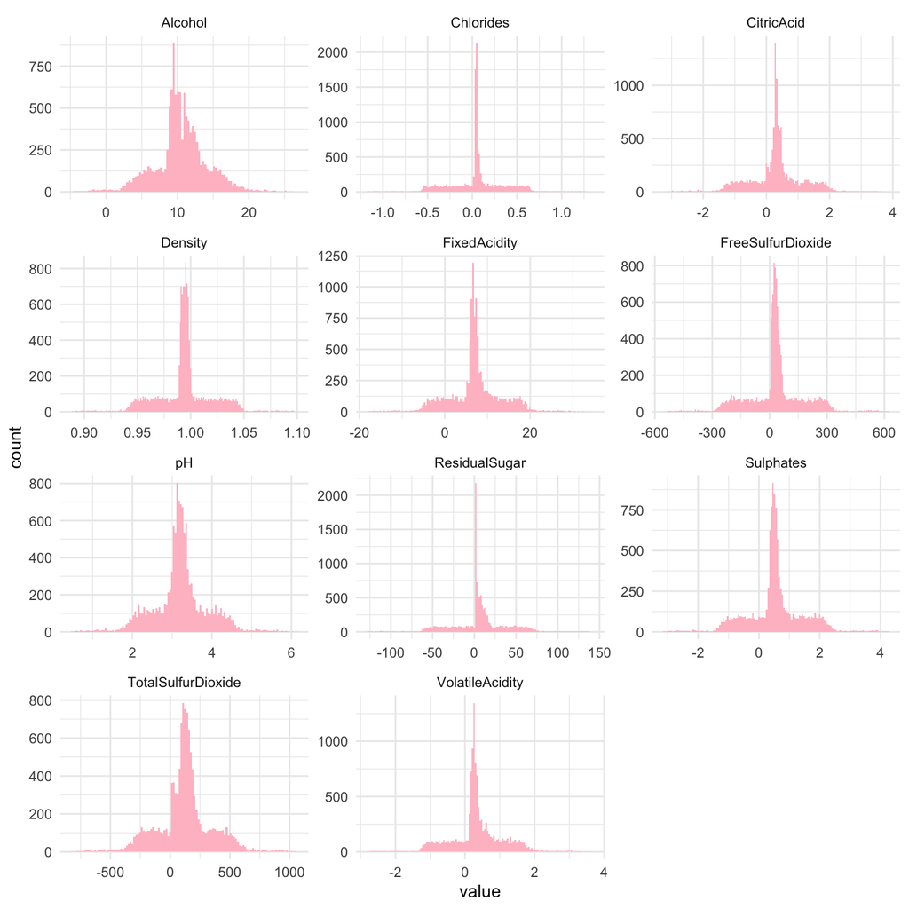

```r
# histogram
data_train %>%
  dplyr::select(-c("AcidIndex", "STARS", "TARGET", "LabelAppeal")) %>%
  gather() %>%
  ggplot(aes(value)) +
  facet_wrap(~key, scale = "free",  ncol = 3) +
  geom_histogram(binwidth = function(x) 2 * IQR(x) / (length(x)^(1/3)), fill="pink") +
  theme_minimal()
```

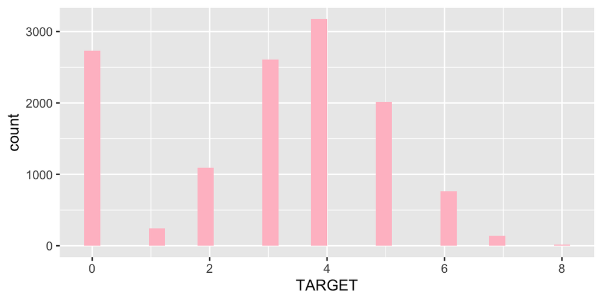

```r
data_train %>%
  ggplot(aes(x=TARGET)) +
  geom_histogram(fill='pink')
```

In the box plot below, we plot several variables in to two panels. TotalSulfurDioxide, FreeSulfurDioxide, and ResidualSugar variables have large ranges compared to other variables. Therefore, we separated those variables in to a different panel to view their distribution. From both panel, we can tell a high number of variables have numerous outliers.

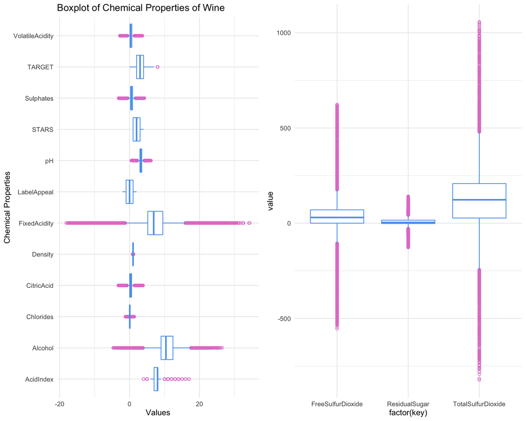

```r
library(ggpubr)
# boxplot
p1 <- data_train %>%
  dplyr::select(-c("TotalSulfurDioxide", "FreeSulfurDioxide", "ResidualSugar")) %>%
  gather(na.rm = TRUE) %>%
  ggplot(aes(factor(key), value)) +
  geom_boxplot(outlier.colour = "#e281cf", outlier.shape = 1,  color = "#5aa1ed") +
  coord_flip() +
  labs(title = "Boxplot of Chemical Properties of Wine", x = "Chemical Properties", y = "Values") +
  theme_minimal()
p2 <- data_train %>%
  dplyr::select(c("TotalSulfurDioxide", "FreeSulfurDioxide", "ResidualSugar")) %>%
  gather(na.rm = TRUE) %>%
  ggplot(aes(factor(key), value)) +
  geom_boxplot(outlier.colour = "#e281cf", outlier.shape = 1, color = "#5aa1ed") +
  #labs(title = "Boxplot of Chemical Properties of Wine", x = "Chemical Properties", y = "Values") +
  theme_minimal()
ggarrange(p1, p2)
```

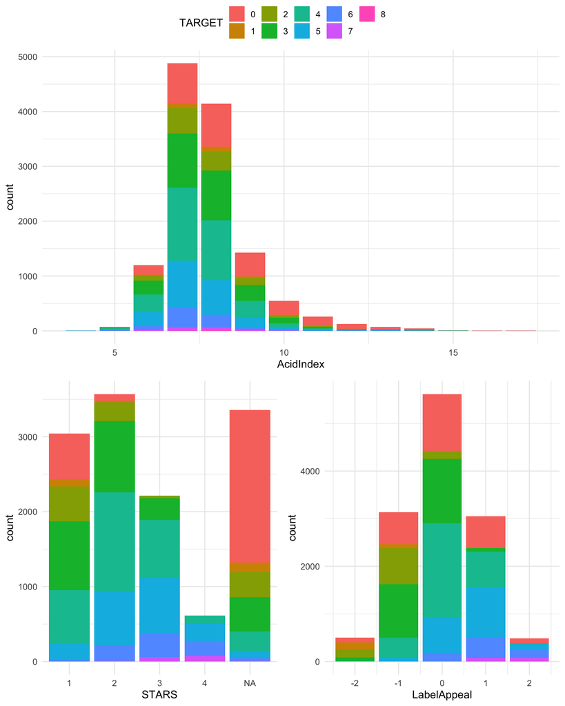

```r
# barchart
p3 <- data_train %>%
  dplyr::select(TARGET, STARS) %>%
  mutate(STARS = as.factor(STARS),
         TARGET = as.factor(TARGET)) %>%
  ggplot(aes(STARS)) +
  geom_bar(aes(fill = TARGET)) +
  theme_minimal()
p4 <- data_train %>%
  dplyr::select(TARGET, LabelAppeal) %>%
  mutate(STARS = as.factor(LabelAppeal),
         TARGET = as.factor(TARGET)) %>%
  ggplot(aes(LabelAppeal)) +
  geom_bar(aes(fill = TARGET)) +
  theme_minimal()
p5 <- data_train %>%
  dplyr::select(TARGET, AcidIndex) %>%
  mutate(STARS = as.factor(AcidIndex),
         TARGET = as.factor(TARGET)) %>%
  ggplot(aes(AcidIndex)) +
  geom_bar(aes(fill = TARGET)) +
  theme_minimal()
ggarrange(p5, ggarrange(p3, p4, ncol = 2, nrow = 1, legend = "none"), nrow = 2, common.legend = TRUE)
```

#### Correlations with Response Variable

```r
# top correlation
wine_train_corr <- data_train %>%
  drop_na() %>%
  cor()
kable(sort(wine_train_corr[,1], decreasing = T), col.names = c("Correlation")) %>%
  kable_styling(full_width = F)
```

|  | Correlation |
| --- | --- |
| TARGET | 1.0000000 |
| STARS | 0.5546857 |
| LabelAppeal | 0.4979465 |
| Alcohol | 0.0737771 |
| FreeSulfurDioxide | 0.0226398 |
| TotalSulfurDioxide | 0.0216021 |
| ResidualSugar | 0.0035196 |
| CitricAcid | 0.0023450 |
| pH | 0.0002199 |
| FixedAcidity | -0.0125381 |
| Sulphates | -0.0212204 |
| Chlorides | -0.0304301 |
| Density | -0.0475989 |
| VolatileAcidity | -0.0759979 |
| AcidIndex | -0.1676431 |

In the correlation table and plot below, we see, `STARS` and `LabelAppeal` are most positively correlated variables with the response variable. We expected this because our variable description mentions these variable’s theoretical affect are higher than other variables. Also, we some mild negative correlation between the response variable and `AcidIndex` variable.

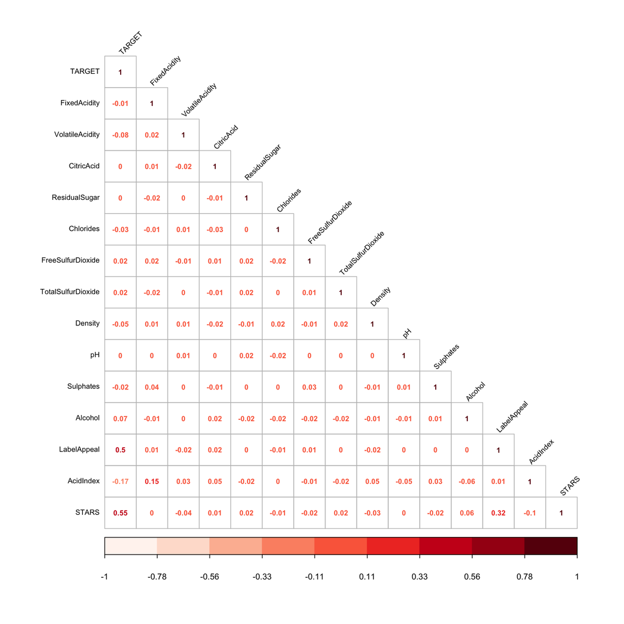

```r
library(corrplot)
library(RColorBrewer)
# correlation plot
corrplot(wine_train_corr,
         method = "number",
         type = "lower",
         col = brewer.pal(n = 15, name = "Reds"),
         number.cex = .7, tl.cex = .7,
         tl.col = "black", tl.srt = 45)
```

## Data Preparation

Using the `aggr` function from `VIM package`, We see several variables have missing values. According to UCI Machine Learning, who published this dataset, all wine contain some natural sulfites. Therefore, we will impute the missing values for sulfite chemical properties. Also, it’s rare to find wines with less than 1 gram/liter of sugar. We will impute this as well. Matter of fact, since all missing values are missing at random, we will impute all the missing values using the mice package and random forest method. Mice uses multivariate imputations to estimate the missing values. Using multiple imputations helps in resolving the uncertainty for the missingness. Our target variable will be removed as a predictor variable but still will be imputed. Our response variables will be removed as predictor variables but still will be imputed.

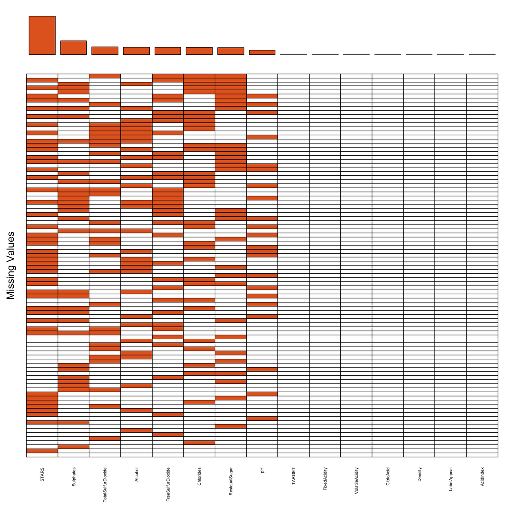

```
 Variables sorted by number of missings:
           Variable Count
              STARS  3359
          Sulphates  1210
 TotalSulfurDioxide   682
            Alcohol   653
  FreeSulfurDioxide   647
          Chlorides   638
      ResidualSugar   616
                 pH   395
             TARGET     0
       FixedAcidity     0
    VolatileAcidity     0
         CitricAcid     0
            Density     0
        LabelAppeal     0
          AcidIndex     0
```

```r
library(VIM)
# missing value columns
aggr(data_train,
     sortVars=TRUE,
     labels=names(data_train),
     cex.axis=.5,
     bars = FALSE,
     col = c("white", "#E46726"),
     combined = TRUE,
     #border = NA,
     ylab = "Missing Values")
```

```r
library(mice)
# imputating train data
init <- mice(data_train)
meth <- init$method
predM <- init$predictorMatrix
predM[, c("TARGET")] <- 0 #this code will remove the variable as a predictor but still will be imputed
data_train_impute <- mice(data_train, method = 'rf', predictorMatrix=predM)
data_train_imputed <- complete(data_train_impute)
print(paste0("Missing value after imputation: ", sum(is.na(data_train_imputed))))
```

```
[1] "Missing value after imputation: 0"
```

## Model Building

### Model 1: Poisson (Raw data)

```r
# poisson model with the missing values
model1 <- glm(TARGET ~ ., family = poisson, data_train)
summary(model1)
```

```
Call:
glm(formula = TARGET ~ ., family = poisson, data = data_train)

Deviance Residuals:
    Min       1Q   Median       3Q      Max
-3.2158  -0.2734   0.0616   0.3732   1.6830

Coefficients:
                     Estimate Std. Error z value Pr(>|z|)
(Intercept)         1.593e+00  2.506e-01   6.359 2.03e-10 ***
FixedAcidity        3.293e-04  1.053e-03   0.313  0.75447
VolatileAcidity    -2.560e-02  8.353e-03  -3.065  0.00218 **
CitricAcid         -7.259e-04  7.575e-03  -0.096  0.92365
ResidualSugar      -6.141e-05  1.941e-04  -0.316  0.75165
Chlorides          -3.007e-02  2.056e-02  -1.463  0.14346
FreeSulfurDioxide   6.734e-05  4.404e-05   1.529  0.12620
TotalSulfurDioxide  2.081e-05  2.855e-05   0.729  0.46618
Density            -3.725e-01  2.462e-01  -1.513  0.13026
pH                 -4.661e-03  9.598e-03  -0.486  0.62722
Sulphates          -5.164e-03  7.051e-03  -0.732  0.46398
Alcohol             3.948e-03  1.771e-03   2.229  0.02579 *
LabelAppeal         1.771e-01  7.954e-03  22.271  < 2e-16 ***
AcidIndex          -4.870e-02  5.903e-03  -8.251  < 2e-16 ***
STARS               1.871e-01  7.487e-03  24.993  < 2e-16 ***
---
Signif. codes:  0 '***' 0.001 '**' 0.01 '*' 0.05 '.' 0.1 ' ' 1

(Dispersion parameter for poisson family taken to be 1)

    Null deviance: 5844.1  on 6435  degrees of freedom
Residual deviance: 4009.1  on 6421  degrees of freedom
  (6359 observations deleted due to missingness)
AIC: 23172

Number of Fisher Scoring iterations: 5
```

```r
print('Goodness of Fit Test:')
```

```
[1] "Goodness of Fit Test:"
```

```r
with(model1, cbind(res.deviance = deviance, df = df.residual,  p = pchisq(deviance, df.residual, lower.tail=FALSE)))
```

```
     res.deviance   df p
[1,]     4009.142 6421 1
```

The deviance residuals is quite symmetrical. This means that the predicted points are close to actual observed points. As expected and seen in our correlation table, `STARS`, `LabelAppeal` and `AcidIndex` are significant variables. And the variation in standard error is low. The goodness of fit test has a high p value which indicates that the model fits the data well.

### Model 2: Poisson (Imputed Data)

```r
# poisson model with the imputed values
model2 <- glm(TARGET ~ ., family = poisson, data_train_imputed)
summary(model2)
```

```
Call:
glm(formula = TARGET ~ ., family = poisson, data = data_train_imputed)

Deviance Residuals:
    Min       1Q   Median       3Q      Max
-4.2375  -0.5140   0.2139   0.6265   2.5573

Coefficients:
                     Estimate Std. Error z value Pr(>|z|)
(Intercept)         2.020e+00  1.955e-01  10.331  < 2e-16 ***
FixedAcidity       -3.926e-04  8.194e-04  -0.479 0.631854
VolatileAcidity    -4.870e-02  6.486e-03  -7.507 6.03e-14 ***
CitricAcid          1.263e-02  5.891e-03   2.144 0.032025 *
ResidualSugar       1.644e-04  1.515e-04   1.085 0.277860
Chlorides          -5.719e-02  1.615e-02  -3.542 0.000397 ***
FreeSulfurDioxide   1.492e-04  3.448e-05   4.326 1.52e-05 ***
TotalSulfurDioxide  1.017e-04  2.221e-05   4.578 4.68e-06 ***
Density            -3.779e-01  1.919e-01  -1.969 0.048955 *
pH                 -2.450e-02  7.565e-03  -3.239 0.001200 **
Sulphates          -1.833e-02  5.542e-03  -3.308 0.000941 ***
Alcohol             5.327e-03  1.385e-03   3.847 0.000120 ***
LabelAppeal         1.951e-01  6.039e-03  32.309  < 2e-16 ***
AcidIndex          -1.216e-01  4.455e-03 -27.307  < 2e-16 ***
STARS               1.946e-01  5.799e-03  33.566  < 2e-16 ***
---
Signif. codes:  0 '***' 0.001 '**' 0.01 '*' 0.05 '.' 0.1 ' ' 1

(Dispersion parameter for poisson family taken to be 1)

    Null deviance: 22861  on 12794  degrees of freedom
Residual deviance: 18447  on 12780  degrees of freedom
AIC: 50419

Number of Fisher Scoring iterations: 5
```

```r
print('Goodness of Fit Test:')
```

```
[1] "Goodness of Fit Test:"
```

```r
with(model2, cbind(res.deviance = deviance, df = df.residual, p = pchisq(deviance, df.residual, lower.tail=FALSE)))
```

```
     res.deviance    df             p
[1,]     18446.92 12780 1.038084e-214
```

Given what we observed when looking at the distribution of `TARGET`, we should expext the inflated count of zeros to affect the model and bias results. For this reason, we move to a zero-inflated model to reflect this.

### Model 3: Quasipoisson Model

We try a quasipoisson model to account for nay overdispersion and to see if the results change significantly. As seen in the summary below, the models are nearly identical.

```r
# poisson model with the imputed values
model3 <- glm(TARGET ~ ., family = quasipoisson(link='log'), data_train_imputed)
summary(model3)
```

```
Call:
glm(formula = TARGET ~ ., family = quasipoisson(link = "log"),
    data = data_train_imputed)

Deviance Residuals:
    Min       1Q   Median       3Q      Max
-4.2375  -0.5140   0.2139   0.6265   2.5573

Coefficients:
                     Estimate Std. Error t value Pr(>|t|)
(Intercept)         2.020e+00  1.914e-01  10.556  < 2e-16 ***
FixedAcidity       -3.926e-04  8.019e-04  -0.490 0.624443
VolatileAcidity    -4.870e-02  6.348e-03  -7.671 1.83e-14 ***
CitricAcid          1.263e-02  5.765e-03   2.191 0.028478 *
ResidualSugar       1.644e-04  1.483e-04   1.109 0.267529
Chlorides          -5.719e-02  1.580e-02  -3.619 0.000296 ***
FreeSulfurDioxide   1.492e-04  3.374e-05   4.421 9.91e-06 ***
TotalSulfurDioxide  1.017e-04  2.173e-05   4.678 2.92e-06 ***
Density            -3.779e-01  1.878e-01  -2.012 0.044246 *
pH                 -2.450e-02  7.404e-03  -3.310 0.000937 ***
Sulphates          -1.833e-02  5.424e-03  -3.380 0.000727 ***
Alcohol             5.327e-03  1.355e-03   3.931 8.51e-05 ***
LabelAppeal         1.951e-01  5.910e-03  33.014  < 2e-16 ***
AcidIndex          -1.216e-01  4.360e-03 -27.903  < 2e-16 ***
STARS               1.946e-01  5.675e-03  34.298  < 2e-16 ***
---
Signif. codes:  0 '***' 0.001 '**' 0.01 '*' 0.05 '.' 0.1 ' ' 1

(Dispersion parameter for quasipoisson family taken to be 0.9577432)

    Null deviance: 22861  on 12794  degrees of freedom
Residual deviance: 18447  on 12780  degrees of freedom
AIC: NA

Number of Fisher Scoring iterations: 5
```

```r
print('Goodness of Fit Test:')
```

```
[1] "Goodness of Fit Test:"
```

```r
with(model3, cbind(res.deviance = deviance, df = df.residual, p = pchisq(deviance, df.residual, lower.tail=FALSE)))
```

```
     res.deviance    df             p
[1,]     18446.92 12780 1.038084e-214
```

### Model 4: Zero Inflated

We saw earlier that the dependent variable had an excess number of zeros which skewed the distribution from a typical poisson. The zero inflated model generates coefficients for the zero count part of the model as well as for the count part.

```r
model4 <- zeroinfl(TARGET ~., data_train_imputed, dist = 'poisson')
summary(model4)
```

```
Call:
zeroinfl(formula = TARGET ~ ., data = data_train_imputed, dist = "poisson")

Pearson residuals:
    Min      1Q  Median      3Q     Max
-2.5523 -0.3699  0.1592  0.4997  4.1466

Count model coefficients (poisson with log link):
                     Estimate Std. Error z value Pr(>|z|)
(Intercept)         1.416e+00  2.068e-01   6.847 7.56e-12 ***
FixedAcidity        3.457e-04  8.573e-04   0.403 0.686765
VolatileAcidity    -1.292e-02  6.876e-03  -1.878 0.060345 .
CitricAcid         -7.268e-04  6.141e-03  -0.118 0.905787
ResidualSugar      -1.076e-04  1.589e-04  -0.677 0.498245
Chlorides          -1.685e-02  1.700e-02  -0.991 0.321551
FreeSulfurDioxide   3.159e-05  3.543e-05   0.892 0.372519
TotalSulfurDioxide -2.811e-05  2.257e-05  -1.246 0.212943
Density            -2.906e-01  2.027e-01  -1.434 0.151694
pH                  6.640e-03  7.965e-03   0.834 0.404528
Sulphates           9.380e-04  5.863e-03   0.160 0.872902
Alcohol             7.578e-03  1.444e-03   5.249 1.53e-07 ***
LabelAppeal         2.509e-01  6.423e-03  39.065  < 2e-16 ***
AcidIndex          -1.695e-02  4.991e-03  -3.396 0.000683 ***
STARS               9.212e-02  6.291e-03  14.644  < 2e-16 ***

Zero-inflation model coefficients (binomial with logit link):
                     Estimate Std. Error z value Pr(>|z|)
(Intercept)        -5.6217507  1.0555623  -5.326 1.00e-07 ***
FixedAcidity        0.0034100  0.0043691   0.780   0.4351
VolatileAcidity     0.2313922  0.0350883   6.595 4.26e-11 ***
CitricAcid         -0.0802892  0.0318198  -2.523   0.0116 *
ResidualSugar      -0.0014474  0.0008129  -1.780   0.0750 .
Chlorides           0.2487335  0.0866513   2.871   0.0041 **
FreeSulfurDioxide  -0.0007772  0.0001843  -4.216 2.49e-05 ***
TotalSulfurDioxide -0.0008167  0.0001184  -6.899 5.25e-12 ***
Density             0.7365822  1.0363870   0.711   0.4773
pH                  0.1942998  0.0406918   4.775 1.80e-06 ***
Sulphates           0.1219135  0.0299885   4.065 4.80e-05 ***
Alcohol             0.0114074  0.0074290   1.536   0.1247
LabelAppeal         0.3612193  0.0338672  10.666  < 2e-16 ***
AcidIndex           0.4786918  0.0199582  23.985  < 2e-16 ***
STARS              -0.6768722  0.0371960 -18.197  < 2e-16 ***
---
Signif. codes:  0 '***' 0.001 '**' 0.01 '*' 0.05 '.' 0.1 ' ' 1

Number of iterations in BFGS optimization: 35
Log-likelihood: -2.248e+04 on 30 Df
```

```r
model4b <- zeroinfl(TARGET ~ . - FixedAcidity - Density, data_train_imputed, dist = 'poisson')
summary(model4b)
```

```
Call:
zeroinfl(formula = TARGET ~ . - FixedAcidity - Density, data = data_train_imputed,
    dist = "poisson")

Pearson residuals:
    Min      1Q  Median      3Q     Max
-2.5516 -0.3710  0.1591  0.4985  3.9624

Count model coefficients (poisson with log link):
                     Estimate Std. Error z value Pr(>|z|)
(Intercept)         1.130e+00  5.243e-02  21.543  < 2e-16 ***
VolatileAcidity    -1.297e-02  6.876e-03  -1.887 0.059225 .
CitricAcid         -6.628e-04  6.140e-03  -0.108 0.914042
ResidualSugar      -1.083e-04  1.589e-04  -0.682 0.495384
Chlorides          -1.743e-02  1.700e-02  -1.025 0.305133
FreeSulfurDioxide   3.086e-05  3.541e-05   0.871 0.383511
TotalSulfurDioxide -2.894e-05  2.256e-05  -1.283 0.199660
pH                  6.653e-03  7.966e-03   0.835 0.403656
Sulphates           1.048e-03  5.862e-03   0.179 0.858106
Alcohol             7.595e-03  1.444e-03   5.261 1.44e-07 ***
LabelAppeal         2.508e-01  6.422e-03  39.059  < 2e-16 ***
AcidIndex          -1.702e-02  4.944e-03  -3.442 0.000578 ***
STARS               9.233e-02  6.290e-03  14.680  < 2e-16 ***

Zero-inflation model coefficients (binomial with logit link):
                     Estimate Std. Error z value Pr(>|z|)
(Intercept)        -4.8891475  0.2417675 -20.223  < 2e-16 ***
VolatileAcidity     0.2321447  0.0350717   6.619 3.61e-11 ***
CitricAcid         -0.0806133  0.0317915  -2.536   0.0112 *
ResidualSugar      -0.0014497  0.0008128  -1.784   0.0745 .
Chlorides           0.2492837  0.0866164   2.878   0.0040 **
FreeSulfurDioxide  -0.0007745  0.0001843  -4.202 2.65e-05 ***
TotalSulfurDioxide -0.0008167  0.0001184  -6.900 5.20e-12 ***
pH                  0.1942247  0.0406838   4.774 1.81e-06 ***
Sulphates           0.1223315  0.0299698   4.082 4.47e-05 ***
Alcohol             0.0113516  0.0074270   1.528   0.1264
LabelAppeal         0.3601954  0.0338376  10.645  < 2e-16 ***
AcidIndex           0.4818269  0.0196286  24.547  < 2e-16 ***
STARS              -0.6765979  0.0371710 -18.202  < 2e-16 ***
---
Signif. codes:  0 '***' 0.001 '**' 0.01 '*' 0.05 '.' 0.1 ' ' 1

Number of iterations in BFGS optimization: 31
Log-likelihood: -2.248e+04 on 26 Df
```

## Model Selection

Based on the models tested, we select the Zero Inflated model due to the highest accuracy of the 4 models

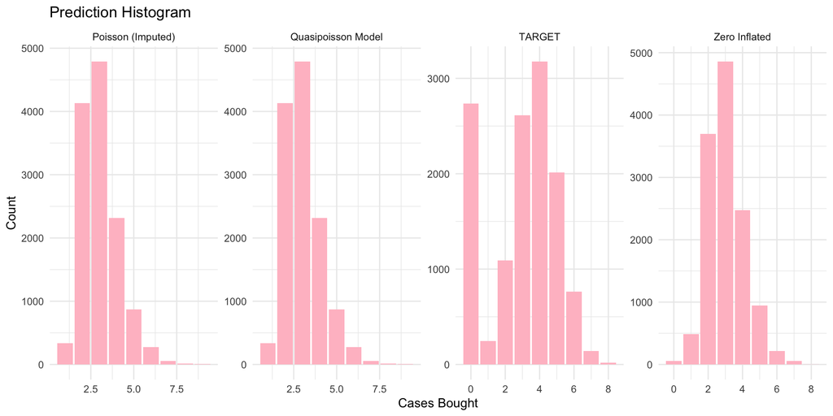

```r
pred_train <- data.frame(TARGET=data_train_imputed$TARGET,
                         model2=model2$fitted.values,
                         model3=model3$fitted.values,
                         model4b=model4b$fitted.values)
pred_train <- round(pred_train, 0)
colnames(pred_train) <- c("TARGET","Poisson (Imputed)" ,"Quasipoisson Model", "Zero Inflated")

pred_train %>%
  gather() %>%
  ggplot(aes(value)) +
  facet_wrap(~key, scale = "free",  ncol = 4) +
  geom_bar(fill="pink") +
  theme_minimal() + labs(x="Cases Bought", y = "Count", title = "Prediction Histogram")
```

```r
model2_fitted.values <- factor(round(model2$fitted.values),levels=rev(0:9))
model3_fitted.values <- factor(round(model3$fitted.values),levels=rev(0:9))
model4b_fitted.values <- factor(round(model4b$fitted.values),levels=rev(0:9))


m2_cfm <- confusionMatrix(model2_fitted.values, factor(data_train_imputed$TARGET,levels=rev(0:9)))
m3_cfm <- confusionMatrix(model3_fitted.values, factor(data_train_imputed$TARGET,levels=rev(0:9)))
m4_cfm <- confusionMatrix(model4b_fitted.values, factor(data_train_imputed$TARGET,levels=rev(0:9)))

models_sum <- data.frame(m2_cfm$overall, m3_cfm$overall, m4_cfm$overall)
colnames(models_sum) <- c("Poisson (Imputed)" ,"Quasipoisson Model", "Zero Inflated")
round(models_sum, 2)
```

|  | Poisson (Imputed) | Quasipoisson Model | Zero Inflated |
| --- | --- | --- | --- |
| Accuracy | 0.25 | 0.25 | 0.27 |
| Kappa | 0.10 | 0.10 | 0.13 |
| AccuracyLower | 0.24 | 0.24 | 0.26 |
| AccuracyUpper | 0.25 | 0.25 | 0.28 |
| AccuracyNull | 0.25 | 0.25 | 0.25 |
| AccuracyPValue | 0.66 | 0.66 | 0.00 |
| McnemarPValue | NaN | NaN | NaN |

```r
init <- mice(data_test)
meth <- init$method
predM <- init$predictorMatrix
predM[, c("TARGET")] <- 0 #this code will remove the variable as a predictor but still will be imputed
data_test_impute <- mice(data_test, method = 'rf', predictorMatrix=predM)
data_test_imputed <- complete(data_test_impute)
print(paste0("Missing value after imputation: ", sum(is.na(data_test_imputed))))
```

```
[1] "Missing value after imputation: 3335"
```

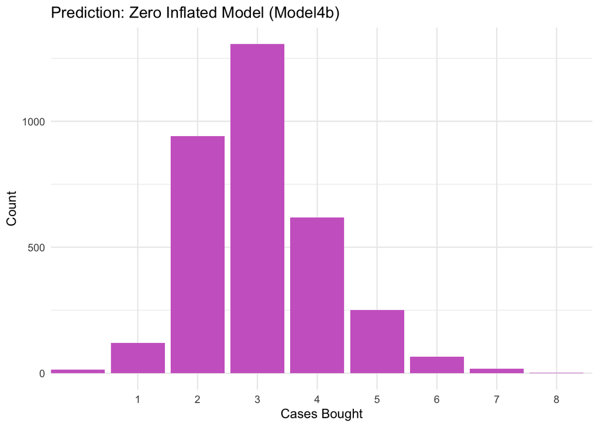

```r
test_predict <- predict(model4b, newdata=data_test_imputed)
test_predict <- round(test_predict,0)
data_pred <- data.frame(TARGET=test_predict)

ggplot(data_pred, aes(x=TARGET)) + geom_bar(fill="orchid3") + theme_minimal() +
  labs(y="Count", title = "Prediction: Zero Inflated Model (Model4b)") +
    scale_x_discrete(name = "Cases Bought", limits=c("1","2","3","4", "5", "6", "7", "8"))
```

```r
write.csv(test_predict, "WinePredictions.csv")
```